# PRAC 2 - Tipologia i cicle de vida de les dades

Marc Blanchart Forné - Universitat Oberta de Catalunya

## Apartat 1

### Descripció del dataset

Per a la realitzacio d'aquesta pràctica, hem optat per analitzar el dataset que conté dades sobre les alicacions que es poden trobar al Google Play (mercat d'aplicacions móvils d'android).

Aquest dataset es pot trobar a Kaggle en el següent link: https://www.kaggle.com/lava18/google-play-store-apps

Amb aquest dataset pretenem trobar els patrons de consum d'aplicacions móvils: quines són les aplicacions més descarregades, més rentables, les més cares, les que tenen millor valoració, etc...

Aquesta informació ens seria de molta utilitat si som un estudi de creació d'aplicacions. Sabriem quines característiques poden fer que una nova aplicació que desenvolupem, tingui èxit o no.

Aquest dataset està format per dos fitxer CSV. Anem a analitzar cada un dels valors dels dos fitxers:

*googleplaystore.csv*:

1. **App**: el nom complet de l'aplicació en questió
2. **Category**: categoria que pertany l'aplicació
3. **Rating**: puntuació mitjana de l'aplicació al mercat
4. **Reviews**: nombre de reviews que té aquella aplicació al mercat
5. **Size**: Tamany que ocupa la aplicació al móvil
6. **Installs**: número de vegades que aquesta aplicació ha estat descarregada i instalada pels usuaris
7. **Type**: Si l'aplicació és gratis o de pagament.
8. **Price**: Preu de l'app en el cas que sigui de pagament
9. **Content Rating**: Franja d'edat adequada per a consumir l'aplicació
10. **Genres**: genere a la que pertany l'aplicació en concret
11. **Last Updated**: Data de l'última modificació de l'app
12. **Current Ver**: Versió actual de l'app
13. **Android Ver**: Versió mínima d'Android requerida per a funcionar

_googleplaystore_user*reviews.csv*:

1. **App**: nom complet de l'app
2. **Translated_Review**: review de l'usuari traduïda a l'anglés
3. **Sentiment**: clasificació de la review del usuari (positiu, negatiu o neutral)
4. **Sentiment_Polarity**: puntuació polaritzada del sentiment
5. **Sentiment_Subject**: puntuació subjectiva del sentiment

## Apartat 2

### Integració i selecció de les dades d'interès a analitzar

De les dues taules de dades, només utilitzarem la primera. Si l'anàlisis queda curt, també analitzarem la segona, però a priori la descartem ja que hauriem de fer un anàlisi de sentiments, cosa que ja s'està fent en una altra asignatura.

Així doncs, anem a importar les llibreries i a carregar les dades:

```python
%matplotlib inline
import warnings
warnings.filterwarnings('ignore')
import pandas as pd
import numpy as np
import matplotlib.pyplot as plt
import seaborn as sns
import plotly

color = sns.color_palette()
sns.set(rc={'figure.figsize':(25,15)})
```

```python
df = pd.read_csv('googleplaystore.csv')
```

Anem a veure els primers cinc registres del dataframe:

```python
print(df.head(5))
```

```
                                                 App        Category  Rating  \
0     Photo Editor & Candy Camera & Grid & ScrapBook  ART_AND_DESIGN     4.1
1                                Coloring book moana  ART_AND_DESIGN     3.9
2  U Launcher Lite – FREE Live Cool Themes, Hide ...  ART_AND_DESIGN     4.7
3                              Sketch - Draw & Paint  ART_AND_DESIGN     4.5
4              Pixel Draw - Number Art Coloring Book  ART_AND_DESIGN     4.3

   Reviews  Size     Installs  Type Price Content Rating  \
0      159   19M      10,000+  Free     0       Everyone
1      967   14M     500,000+  Free     0       Everyone
2    87510  8.7M   5,000,000+  Free     0       Everyone
3   215644   25M  50,000,000+  Free     0           Teen
4      967  2.8M     100,000+  Free     0       Everyone

                      Genres      Last Updated         Current Ver  \
0               Art & Design   January 7, 2018               1.0.0
1  Art & Design;Pretend Play  January 15, 2018               2.0.0
2               Art & Design    August 1, 2018               1.2.4
3               Art & Design      June 8, 2018  Varies with device
4    Art & Design;Creativity     June 20, 2018                 1.1

    Android Ver
0  4.0.3 and up
1  4.0.3 and up
2  4.0.3 and up
3    4.2 and up
4    4.4 and up
```

Anem a mirar el tamany inicial del dataset:

```python
print(df.shape)
```

```
(10841, 13)
```

Anem a mirar si els atributs que tenim corresponen amb la llista mostrada anteriorment:

```python
print(df.columns)
```

```
Index(['App', 'Category', 'Rating', 'Reviews', 'Size', 'Installs', 'Type',
       'Price', 'Content Rating', 'Genres', 'Last Updated', 'Current Ver',
       'Android Ver'],
      dtype='object')
```

De totes aquestes columnes, a priori, farem servir totes ja que totes ens poden aportar valor. Així doncs podem passat directament a l'etapa de neteja.

### Neteja de dades

#### Missing data

Anem a mirar si les nostres dades tenen valors buits o zeros que ens puguin afectar al nostre análisi. Per a fer-ho, mirarmem una per una cada una de les variables.

```python
print(df.isnull().any())
```

```
App               False
Category          False
Rating             True
Reviews           False
Size              False
Installs          False
Type               True
Price             False
Content Rating    False
Genres            False
Last Updated      False
Current Ver        True
Android Ver        True
dtype: bool
```

```python
print(df.isnull().sum())
```

```
App                  0
Category             0
Rating            1474
Reviews              0
Size                 0
Installs             0
Type                 1
Price                0
Content Rating       0
Genres               0
Last Updated         0
Current Ver          8
Android Ver          2
dtype: int64
```

Com veiem, la més problemàtica és la columna Rating, on tenim bastantes aplicacions sense valoració.

Una primera opció seria descartar aquestes entrades, i per tant eliminar-les del nostre dataset. Tanmateix, creiem que perdre aquest valors no seria del tot correcte, ja que les apps són totalment vàlides i el fet que no siguin ratejades pot voler dir que són noves simplement. Per tant, hem decidit aplicar la mitja de la categoria per assignar el rating de les apps que no en tenen. Anem a fer-ho:

```python
df['Rating'] = df.groupby('Category').transform(lambda x: x.fillna(x.mean()))
```

Pel que fa al valor type, veiem com només tenim una aplicació que no sabem si es de pagament o gratis. Hem detectat quina aplicació és, i em vist que es tracte de Command & Conquer: Rivals. Si la busquem al Play Sotre manualment, veiem com és gratis: https://play.google.com/store/apps/details?id=com.ea.gp.candcwarzones&hl=en_US

Per tant, assignem Free a aquesta entrada.

```python
df['Type'] = df['Type'].fillna('Free')
```

Continuem amb les versions d'Android. Aqui tenim varies aplicacions, i el que farem serà inicialitzar-les totes al valor "Varies with the device" ja que és la opció més estandar de totes.

```python
df['Current Ver'] = df['Current Ver'].fillna("Varies with device")
df['Android Ver'] = df['Android Ver'].fillna("Varies with device")
```

Amb això, ja hauriem de tenir tots els valors incorrectes corregits:

```python
print(df.isnull().sum())
```

```
App               0
Category          0
Rating            0
Reviews           0
Size              0
Installs          0
Type              0
Price             0
Content Rating    0
Genres            0
Last Updated      0
Current Ver       0
Android Ver       0
dtype: int64
```

I com veiem, no hem perdut cap mostra:

```python
print(df.shape)
```

```
(10841, 13)
```

Tanmateix, pot passar que tinguem més d'una fila per App, per tant abans de començar, hauriem d'eliminar els reptits si això pasa:

```python
df.App.describe()
```

```
count      10841
unique      9660
top       ROBLOX
freq           9
Name: App, dtype: object
```

Com veiem, tenim 10841 apps però només 9660 uniques, així que hem de borrar els valors repetits:

```python
df.drop_duplicates(subset='App', inplace=True)
```

Per tant, ara hauriem de tenir només aquestes 9660 apps úniques.

```python
print(df.shape)
```

```
(9660, 13)
```

```python
df
```

|  | App | Category | Rating | Reviews | Size | Installs | Type | Price | Content Rating | Genres | Last Updated | Current Ver | Android Ver |
| --- | --- | --- | --- | --- | --- | --- | --- | --- | --- | --- | --- | --- | --- |
| 0 | Photo Editor & Candy Camera & Grid & ScrapBook | ART_AND_DESIGN | 4.100000 | 159 | 19M | 10,000+ | Free | 0 | Everyone | Art & Design | January 7, 2018 | 1.0.0 | 4.0.3 and up |
| 1 | Coloring book moana | ART_AND_DESIGN | 3.900000 | 967 | 14M | 500,000+ | Free | 0 | Everyone | Art & Design;Pretend Play | January 15, 2018 | 2.0.0 | 4.0.3 and up |
| 2 | U Launcher Lite – FREE Live Cool Themes, Hide ... | ART_AND_DESIGN | 4.700000 | 87510 | 8.7M | 5,000,000+ | Free | 0 | Everyone | Art & Design | August 1, 2018 | 1.2.4 | 4.0.3 and up |
| 3 | Sketch - Draw & Paint | ART_AND_DESIGN | 4.500000 | 215644 | 25M | 50,000,000+ | Free | 0 | Teen | Art & Design | June 8, 2018 | Varies with device | 4.2 and up |
| 4 | Pixel Draw - Number Art Coloring Book | ART_AND_DESIGN | 4.300000 | 967 | 2.8M | 100,000+ | Free | 0 | Everyone | Art & Design;Creativity | June 20, 2018 | 1.1 | 4.4 and up |
| 5 | Paper flowers instructions | ART_AND_DESIGN | 4.400000 | 167 | 5.6M | 50,000+ | Free | 0 | Everyone | Art & Design | March 26, 2017 | 1.0 | 2.3 and up |
| 6 | Smoke Effect Photo Maker - Smoke Editor | ART_AND_DESIGN | 3.800000 | 178 | 19M | 50,000+ | Free | 0 | Everyone | Art & Design | April 26, 2018 | 1.1 | 4.0.3 and up |
| 7 | Infinite Painter | ART_AND_DESIGN | 4.100000 | 36815 | 29M | 1,000,000+ | Free | 0 | Everyone | Art & Design | June 14, 2018 | 6.1.61.1 | 4.2 and up |
| 8 | Garden Coloring Book | ART_AND_DESIGN | 4.400000 | 13791 | 33M | 1,000,000+ | Free | 0 | Everyone | Art & Design | September 20, 2017 | 2.9.2 | 3.0 and up |
| 9 | Kids Paint Free - Drawing Fun | ART_AND_DESIGN | 4.700000 | 121 | 3.1M | 10,000+ | Free | 0 | Everyone | Art & Design;Creativity | July 3, 2018 | 2.8 | 4.0.3 and up |
| 10 | Text on Photo - Fonteee | ART_AND_DESIGN | 4.400000 | 13880 | 28M | 1,000,000+ | Free | 0 | Everyone | Art & Design | October 27, 2017 | 1.0.4 | 4.1 and up |
| 11 | Name Art Photo Editor - Focus n Filters | ART_AND_DESIGN | 4.400000 | 8788 | 12M | 1,000,000+ | Free | 0 | Everyone | Art & Design | July 31, 2018 | 1.0.15 | 4.0 and up |
| 12 | Tattoo Name On My Photo Editor | ART_AND_DESIGN | 4.200000 | 44829 | 20M | 10,000,000+ | Free | 0 | Teen | Art & Design | April 2, 2018 | 3.8 | 4.1 and up |
| 13 | Mandala Coloring Book | ART_AND_DESIGN | 4.600000 | 4326 | 21M | 100,000+ | Free | 0 | Everyone | Art & Design | June 26, 2018 | 1.0.4 | 4.4 and up |
| 14 | 3D Color Pixel by Number - Sandbox Art Coloring | ART_AND_DESIGN | 4.400000 | 1518 | 37M | 100,000+ | Free | 0 | Everyone | Art & Design | August 3, 2018 | 1.2.3 | 2.3 and up |
| 15 | Learn To Draw Kawaii Characters | ART_AND_DESIGN | 3.200000 | 55 | 2.7M | 5,000+ | Free | 0 | Everyone | Art & Design | June 6, 2018 | Varies with device | 4.2 and up |
| 16 | Photo Designer - Write your name with shapes | ART_AND_DESIGN | 4.700000 | 3632 | 5.5M | 500,000+ | Free | 0 | Everyone | Art & Design | July 31, 2018 | 3.1 | 4.1 and up |
| 17 | 350 Diy Room Decor Ideas | ART_AND_DESIGN | 4.500000 | 27 | 17M | 10,000+ | Free | 0 | Everyone | Art & Design | November 7, 2017 | 1.0 | 2.3 and up |
| 18 | FlipaClip - Cartoon animation | ART_AND_DESIGN | 4.300000 | 194216 | 39M | 5,000,000+ | Free | 0 | Everyone | Art & Design | August 3, 2018 | 2.2.5 | 4.0.3 and up |
| 19 | ibis Paint X | ART_AND_DESIGN | 4.600000 | 224399 | 31M | 10,000,000+ | Free | 0 | Everyone | Art & Design | July 30, 2018 | 5.5.4 | 4.1 and up |
| 20 | Logo Maker - Small Business | ART_AND_DESIGN | 4.000000 | 450 | 14M | 100,000+ | Free | 0 | Everyone | Art & Design | April 20, 2018 | 4.0 | 4.1 and up |
| 21 | Boys Photo Editor - Six Pack & Men's Suit | ART_AND_DESIGN | 4.100000 | 654 | 12M | 100,000+ | Free | 0 | Everyone | Art & Design | March 20, 2018 | 1.1 | 4.0.3 and up |
| 22 | Superheroes Wallpapers \| 4K Backgrounds | ART_AND_DESIGN | 4.700000 | 7699 | 4.2M | 500,000+ | Free | 0 | Everyone 10+ | Art & Design | July 12, 2018 | 2.2.6.2 | 4.0.3 and up |
| 23 | Mcqueen Coloring pages | ART_AND_DESIGN | 4.319048 | 61 | 7.0M | 100,000+ | Free | 0 | Everyone | Art & Design;Action & Adventure | March 7, 2018 | 1.0.0 | 4.1 and up |
| 24 | HD Mickey Minnie Wallpapers | ART_AND_DESIGN | 4.700000 | 118 | 23M | 50,000+ | Free | 0 | Everyone | Art & Design | July 7, 2018 | 1.1.3 | 4.1 and up |
| 25 | Harley Quinn wallpapers HD | ART_AND_DESIGN | 4.800000 | 192 | 6.0M | 10,000+ | Free | 0 | Everyone | Art & Design | April 25, 2018 | 1.5 | 3.0 and up |
| 26 | Colorfit - Drawing & Coloring | ART_AND_DESIGN | 4.700000 | 20260 | 25M | 500,000+ | Free | 0 | Everyone | Art & Design;Creativity | October 11, 2017 | 1.0.8 | 4.0.3 and up |
| 27 | Animated Photo Editor | ART_AND_DESIGN | 4.100000 | 203 | 6.1M | 100,000+ | Free | 0 | Everyone | Art & Design | March 21, 2018 | 1.03 | 4.0.3 and up |
| 28 | Pencil Sketch Drawing | ART_AND_DESIGN | 3.900000 | 136 | 4.6M | 10,000+ | Free | 0 | Everyone | Art & Design | July 12, 2018 | 6.0 | 2.3 and up |
| 29 | Easy Realistic Drawing Tutorial | ART_AND_DESIGN | 4.100000 | 223 | 4.2M | 100,000+ | Free | 0 | Everyone | Art & Design | August 22, 2017 | 1.0 | 2.3 and up |
| ... | ... | ... | ... | ... | ... | ... | ... | ... | ... | ... | ... | ... | ... |
| 10811 | FR Plus 1.6 | AUTO_AND_VEHICLES | 4.190411 | 4 | 3.9M | 100+ | Free | 0 | Everyone | Auto & Vehicles | July 24, 2018 | 1.3.6 | 4.4W and up |
| 10812 | Fr Agnel Pune | FAMILY | 4.100000 | 80 | 13M | 1,000+ | Free | 0 | Everyone | Education | June 13, 2018 | 2.0.20 | 4.0.3 and up |
| 10813 | DICT.fr Mobile | BUSINESS | 4.121452 | 20 | 2.7M | 10,000+ | Free | 0 | Everyone | Business | July 17, 2018 | 2.1.10 | 4.1 and up |
| 10814 | FR: My Secret Pets! | FAMILY | 4.000000 | 785 | 31M | 50,000+ | Free | 0 | Teen | Entertainment | June 3, 2015 | 1.3.1 | 3.0 and up |
| 10815 | Golden Dictionary (FR-AR) | BOOKS_AND_REFERENCE | 4.200000 | 5775 | 4.9M | 500,000+ | Free | 0 | Everyone | Books & Reference | July 19, 2018 | 7.0.4.6 | 4.2 and up |
| 10816 | FieldBi FR Offline | BUSINESS | 4.121452 | 2 | 6.8M | 100+ | Free | 0 | Everyone | Business | August 6, 2018 | 2.1.8 | 4.1 and up |
| 10817 | HTC Sense Input - FR | TOOLS | 4.000000 | 885 | 8.0M | 100,000+ | Free | 0 | Everyone | Tools | October 30, 2015 | 1.0.612928 | 5.0 and up |
| 10818 | Gold Quote - Gold.fr | FINANCE | 4.131889 | 96 | 1.5M | 10,000+ | Free | 0 | Everyone | Finance | May 19, 2016 | 2.3 | 2.2 and up |
| 10819 | Fanfic-FR | BOOKS_AND_REFERENCE | 3.300000 | 52 | 3.6M | 5,000+ | Free | 0 | Teen | Books & Reference | August 5, 2017 | 0.3.4 | 4.1 and up |
| 10820 | Fr. Daoud Lamei | FAMILY | 5.000000 | 22 | 8.6M | 1,000+ | Free | 0 | Teen | Education | June 27, 2018 | 3.8.0 | 4.1 and up |
| 10821 | Poop FR | FAMILY | 4.192272 | 6 | 2.5M | 50+ | Free | 0 | Everyone | Entertainment | May 29, 2018 | 1.0 | 4.0.3 and up |
| 10822 | PLMGSS FR | PRODUCTIVITY | 4.211396 | 0 | 3.1M | 10+ | Free | 0 | Everyone | Productivity | December 1, 2017 | 1 | 4.4 and up |
| 10823 | List iptv FR | VIDEO_PLAYERS | 4.063750 | 1 | 2.9M | 100+ | Free | 0 | Everyone | Video Players & Editors | April 22, 2018 | 1.0 | 4.0.3 and up |
| 10824 | Cardio-FR | MEDICAL | 4.189143 | 67 | 82M | 10,000+ | Free | 0 | Everyone | Medical | July 31, 2018 | 2.2.2 | 4.4 and up |
| 10825 | Naruto & Boruto FR | SOCIAL | 4.255598 | 7 | 7.7M | 100+ | Free | 0 | Teen | Social | February 2, 2018 | 1.0 | 4.0 and up |
| 10826 | Frim: get new friends on local chat rooms | SOCIAL | 4.000000 | 88486 | Varies with device | 5,000,000+ | Free | 0 | Mature 17+ | Social | March 23, 2018 | Varies with device | Varies with device |
| 10827 | Fr Agnel Ambarnath | FAMILY | 4.200000 | 117 | 13M | 5,000+ | Free | 0 | Everyone | Education | June 13, 2018 | 2.0.20 | 4.0.3 and up |
| 10828 | Manga-FR - Anime Vostfr | COMICS | 3.400000 | 291 | 13M | 10,000+ | Free | 0 | Everyone | Comics | May 15, 2017 | 2.0.1 | 4.0 and up |
| 10829 | Bulgarian French Dictionary Fr | BOOKS_AND_REFERENCE | 4.600000 | 603 | 7.4M | 10,000+ | Free | 0 | Everyone | Books & Reference | June 19, 2016 | 2.96 | 4.1 and up |
| 10830 | News Minecraft.fr | NEWS_AND_MAGAZINES | 3.800000 | 881 | 2.3M | 100,000+ | Free | 0 | Everyone | News & Magazines | January 20, 2014 | 1.5 | 1.6 and up |
| 10831 | payermonstationnement.fr | MAPS_AND_NAVIGATION | 4.051613 | 38 | 9.8M | 5,000+ | Free | 0 | Everyone | Maps & Navigation | June 13, 2018 | 2.0.148.0 | 4.0 and up |
| 10832 | FR Tides | WEATHER | 3.800000 | 1195 | 582k | 100,000+ | Free | 0 | Everyone | Weather | February 16, 2014 | 6.0 | 2.1 and up |
| 10833 | Chemin (fr) | BOOKS_AND_REFERENCE | 4.800000 | 44 | 619k | 1,000+ | Free | 0 | Everyone | Books & Reference | March 23, 2014 | 0.8 | 2.2 and up |
| 10834 | FR Calculator | FAMILY | 4.000000 | 7 | 2.6M | 500+ | Free | 0 | Everyone | Education | June 18, 2017 | 1.0.0 | 4.1 and up |
| 10835 | FR Forms | BUSINESS | 4.121452 | 0 | 9.6M | 10+ | Free | 0 | Everyone | Business | September 29, 2016 | 1.1.5 | 4.0 and up |
| 10836 | Sya9a Maroc - FR | FAMILY | 4.500000 | 38 | 53M | 5,000+ | Free | 0 | Everyone | Education | July 25, 2017 | 1.48 | 4.1 and up |
| 10837 | Fr. Mike Schmitz Audio Teachings | FAMILY | 5.000000 | 4 | 3.6M | 100+ | Free | 0 | Everyone | Education | July 6, 2018 | 1.0 | 4.1 and up |
| 10838 | Parkinson Exercices FR | MEDICAL | 4.189143 | 3 | 9.5M | 1,000+ | Free | 0 | Everyone | Medical | January 20, 2017 | 1.0 | 2.2 and up |
| 10839 | The SCP Foundation DB fr nn5n | BOOKS_AND_REFERENCE | 4.500000 | 114 | Varies with device | 1,000+ | Free | 0 | Mature 17+ | Books & Reference | January 19, 2015 | Varies with device | Varies with device |
| 10840 | iHoroscope - 2018 Daily Horoscope & Astrology | LIFESTYLE | 4.500000 | 398307 | 19M | 10,000,000+ | Free | 0 | Everyone | Lifestyle | July 25, 2018 | Varies with device | Varies with device |

9660 rows × 13 columns

Un cop tenim això, anem a mirar les variables categòriques i a corregir possibles errors.

Per exemple, per a la variable Install, tenim valors com 10.000+, que vol dir més de 10 mils instal·lacions. Per tal de tractar aquesta variable com categòrica, anem a eliminar els simbols que hi ha (+ i -)

```python
df['Installs'] = df['Installs'].apply(lambda x: x.replace('+', '') if '+' in str(x) else x)
df['Installs'] = df['Installs'].apply(lambda x: x.replace(',', '') if ',' in str(x) else x)
df['Installs'] = df['Installs'].apply(lambda x: float(x))
```

Pel que fa al tamany, com volm obtenir un número per a poder graficar-lo correctament, hem de convertir tots els valors a MB. Algunes aplicacions estan en kB i per tant hem de fer les transformacions i borrar les unitats. Per altras banda, si varia en cada dispositiu, colocarem un valor mitjà de 10MB.

```python
df['Size'] = df['Size'].apply(lambda x: str(x).replace('Varies with device', '10M') if 'Varies with device' in str(x) else x)
df['Size'] = df['Size'].apply(lambda x: str(x).replace('M', '') if 'M' in str(x) else x)
df['Size'] = df['Size'].apply(lambda x: str(x).replace(',', '') if 'M' in str(x) else x)
df['Size'] = df['Size'].apply(lambda x: float(str(x).replace('k', '')) / 1000 if 'k' in str(x) else x)
df['Size'] = df['Size'].apply(lambda x: float(x))
```

Farem el mateix amb el preu, li borrarem les unitats:

```python
df['Price'] = df['Price'].apply(lambda x: str(x).replace('$', '') if '$' in str(x) else str(x))
df['Price'] = df['Price'].apply(lambda x: float(x))
```

```python
df['Reviews'] = df['Reviews'].apply(lambda x: int(x))
```

Un cop fet això, ja tenim les dades preparades.

#### Extreme values

Anem a identificar els valors extrems de cada una de les variables graficant el diagrama de caixes per cada una de les variables no categòriques:

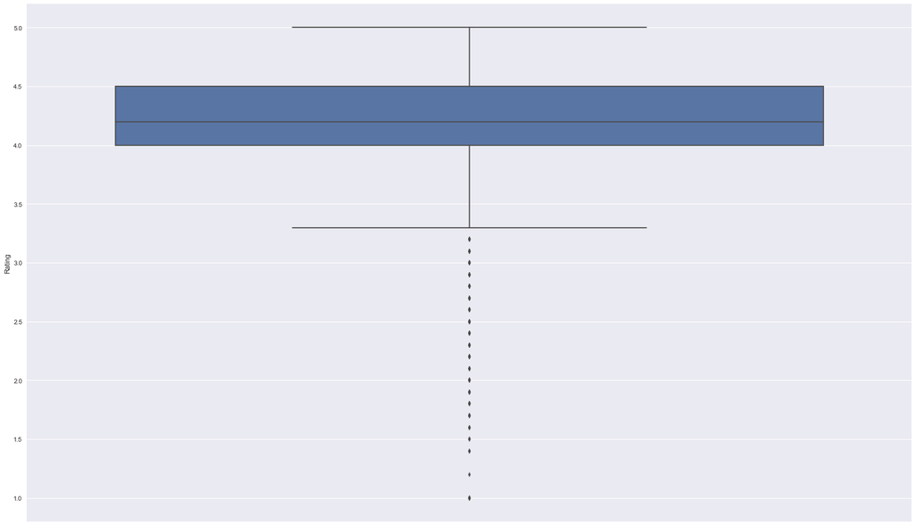

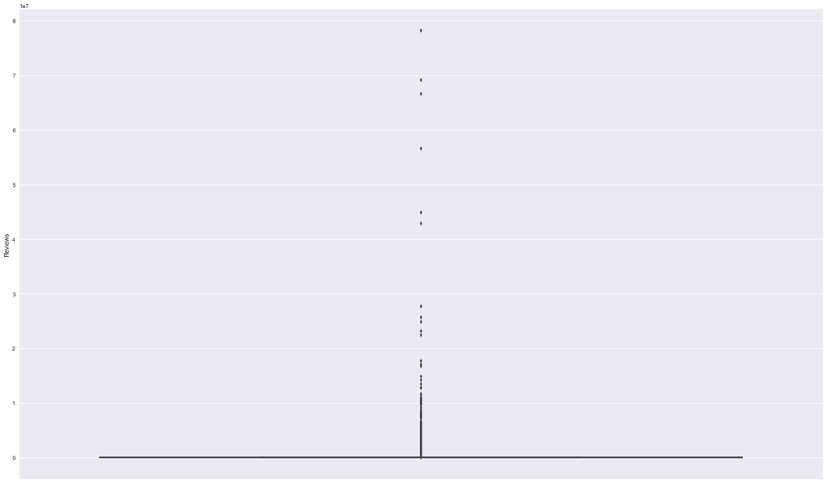

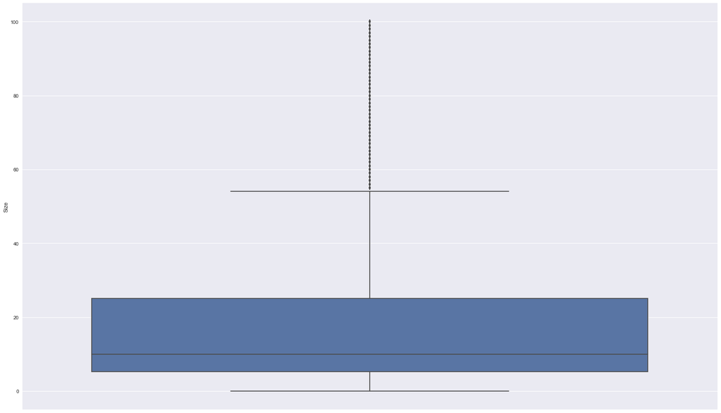

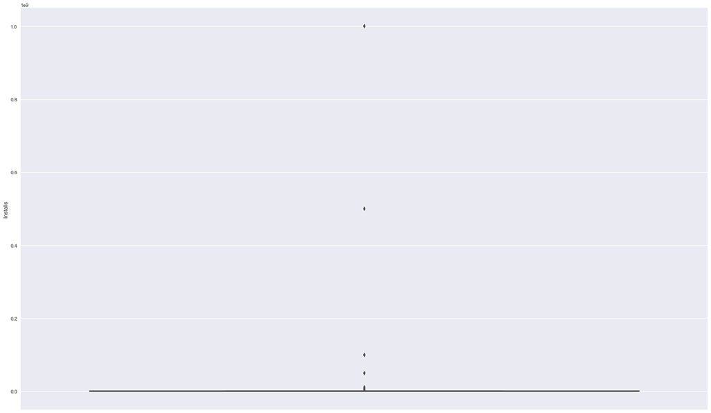

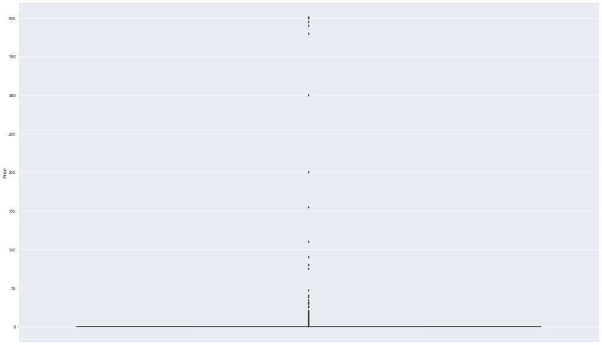

```python
numerical_cols = df._get_numeric_data().columns

for i in numerical_cols:
    sns.boxplot(df[i], orient='vertical')
    plt.show()
```

Com podem veure, les variables no són gens uniformes.

Pel que fa al número de reviews, veiem com normalment les aplicacions tenen poques entrades, però que n'hi ha algunes (les més populars) que poden arribar a tenir-ne fins a 80 milions de comentaris.

El mateix passa amb les instal·lacions, ja que les variables deuen anar força correlades.

Pel que fa al preu, veiem com la majoria d'apps són gratis, però què hi ha alguns valors extrems que poden arribar als 400 dolars.

Aquests valors extrems no sembla que s'hàgin produït per error i per tant els tindrem en compte en el nostre anàlisi.

### Anàlisi de dades

A continuació intentarem mostrar una série de gràfics que ajudin a entendre les dades que tenim.

Hem observat com tan el número de reviews com el número de instalacions segueixen un distribució semblant. Segurament això es deu a que estan fortament correlades. Anem a generar i gràficar aquesta matriu de correlacions.

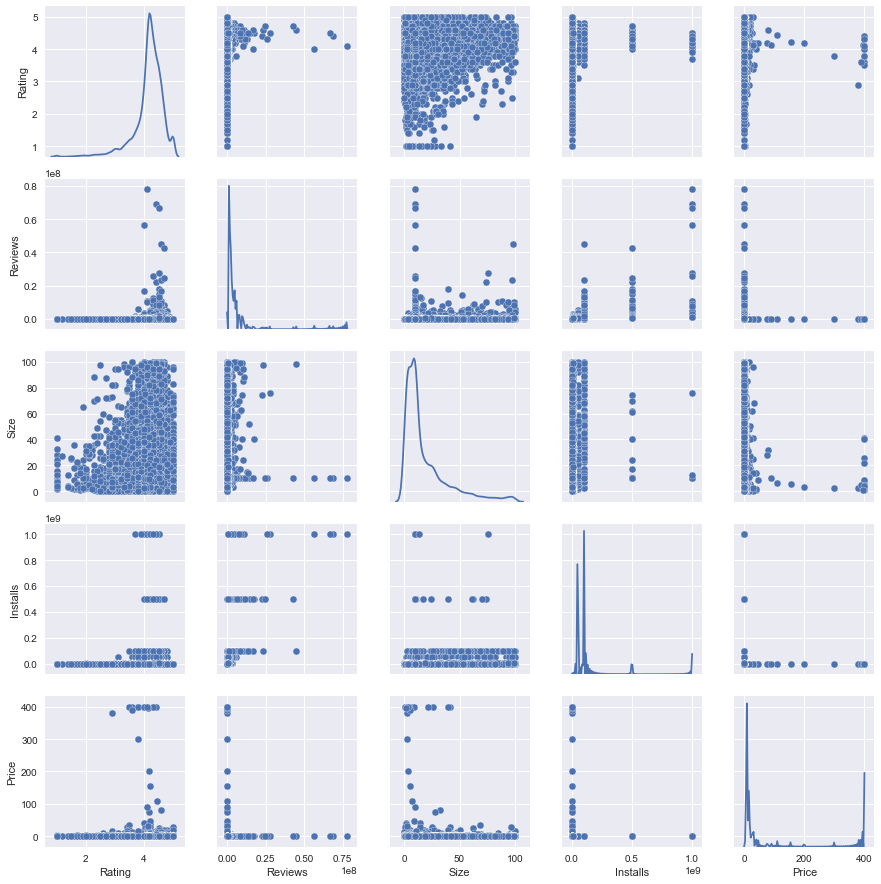

```python
p = sns.pairplot(pd.DataFrame(list(zip(df[numerical_cols[0]],df[numerical_cols[1]],df[numerical_cols[2]],df[numerical_cols[3]],df[numerical_cols[4]])),columns=numerical_cols), diag_kind="kde")
```

Aqui ja veiem com hi ha alguns patrons clars, tanmateix anem a graficar-los númericament:

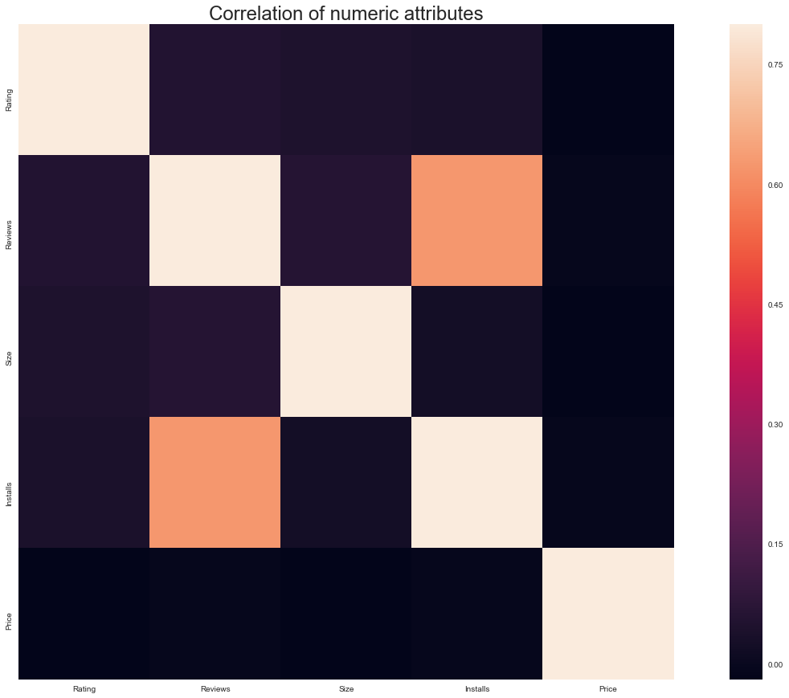

```python
correlation = df[numerical_cols].corr()

title=plt.title('Correlation of numeric attributes',y=1,size=24)
heatmap=sns.heatmap(correlation,square = True,  vmax=0.8)
plt.show(heatmap)
```

Com ja suposavem, veiem com hi ha una gran correlació entre el número de reviews i el número de instal·lacions.

Ara és moment de mirar com es distribueixen les variables categòriques del nostre dataset. Primer de tot, mirarem com es distribueixen cada una d'aquestes variables:

```
Text(0.5,1,'Number of apps in each category')
```

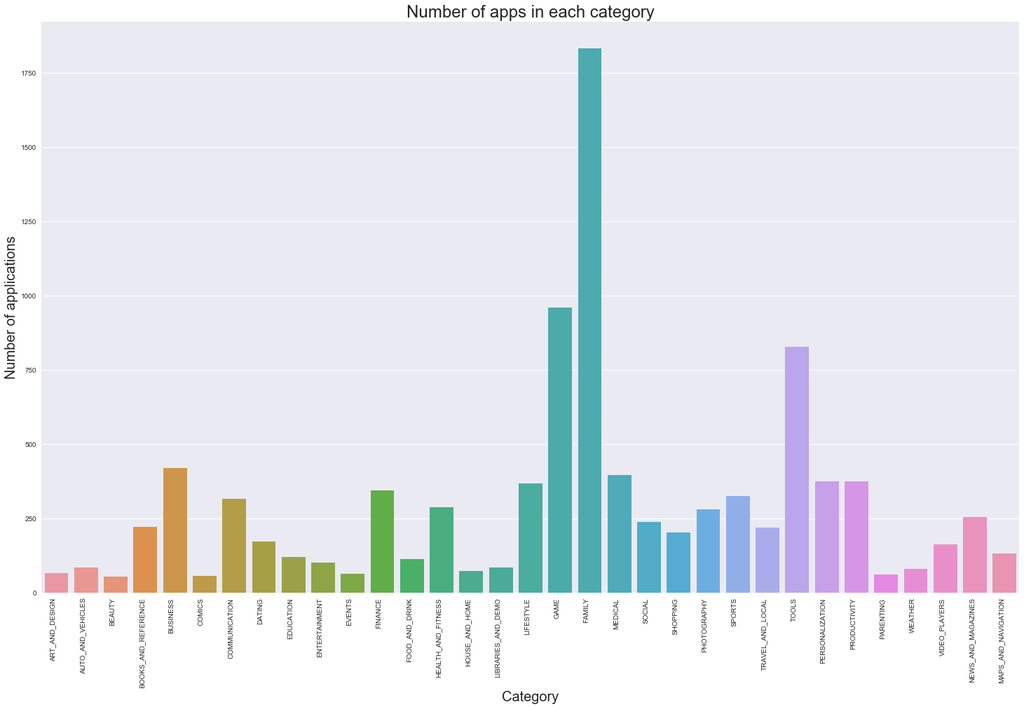

```python
g = sns.countplot(x="Category",data=df)
g.set_xticklabels(g.get_xticklabels(), rotation=90, ha="right")
g.set_ylabel("Number of applications",fontsize=20)
g.set_xlabel("Category",fontsize=20)
plt.title('Number of apps in each category',size = 24)
```

Com veiem, tenim moltes aplicacions distribuides entre les Categories de Familia, Jocs i Eines.

Anem a mirar ara el genere de les aplicacions:

```
Text(0.5,1,'Number of apps in each genres')
```

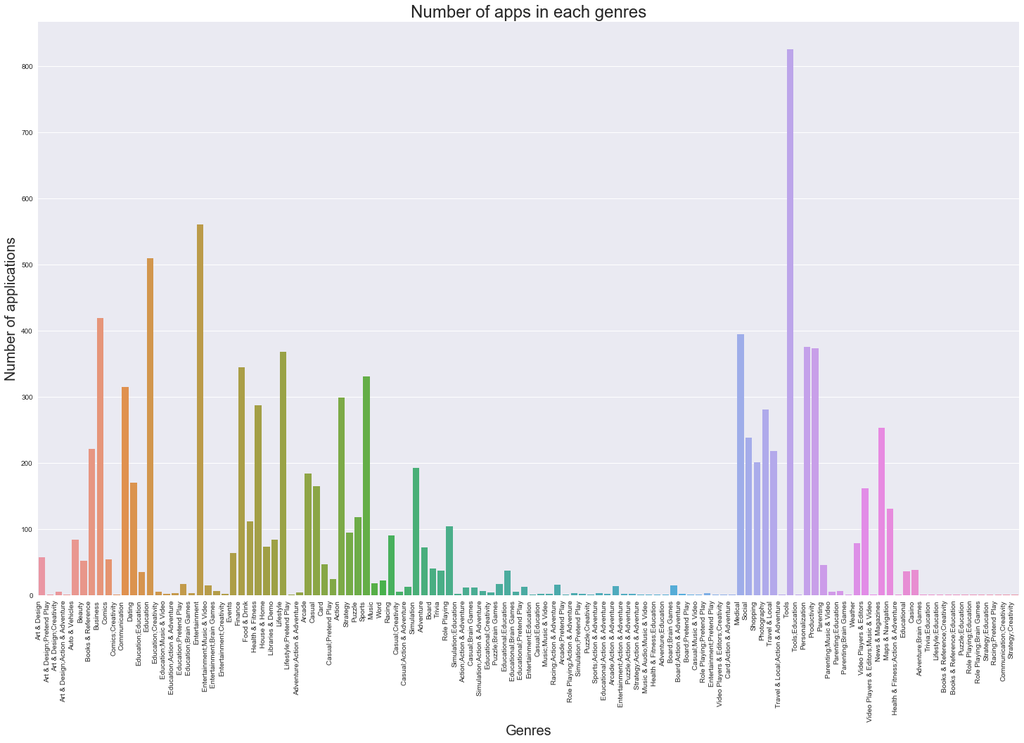

```python
g = sns.countplot(x="Genres",data=df)
g.set_xticklabels(g.get_xticklabels(), rotation=90, ha="right")
g.set_ylabel("Number of applications",fontsize=20)
g.set_xlabel("Genres",fontsize=20)
plt.title('Number of apps in each genres',size = 24)
```

Anem a mirar ara com es distribueixen les apps en funció de si són de pagament o si són gratis:

```
Text(0.5,1,'Number of apps for each type')
```

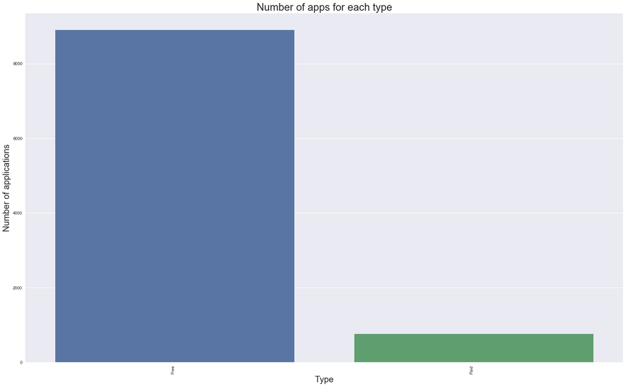

```python
g = sns.countplot(x="Type",data=df)
g.set_xticklabels(g.get_xticklabels(), rotation=90, ha="right")
g.set_ylabel("Number of applications",fontsize=20)
g.set_xlabel("Type",fontsize=20)
plt.title('Number of apps for each type',size = 24)
```

Com veiem, la diferència es clara. Tenim moltes més apps gratis que de pagament. Això ja ho hem vist abans amb el diagrama de caixa de la variable preu.

Anem a veure quin Android mínim requereixen la majoria de Apps:

```
Text(0.5,1,'Number of apps for Android Ver field')
```

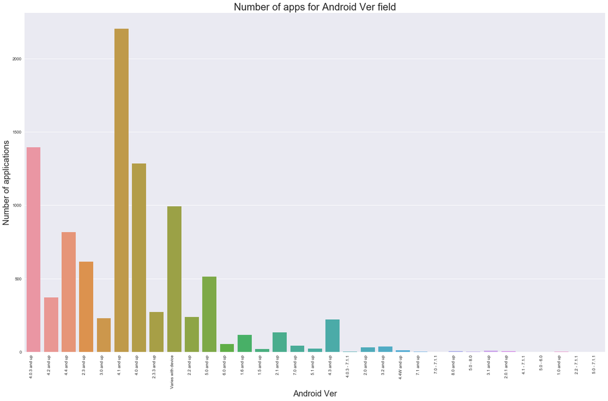

```python
g = sns.countplot(x="Android Ver",data=df)
g.set_xticklabels(g.get_xticklabels(), rotation=90, ha="right")
g.set_ylabel("Number of applications",fontsize=20)
g.set_xlabel("Android Ver",fontsize=20)
plt.title('Number of apps for Android Ver field',size = 24)
```

Aquesta gràfica és molt reveladora, ja que si som un estudi de creació de Apps, hem d'aconsegir que com a mínim la nostre App accepti android 4.1, ja que és la tendència majoritària del mercat. Tanmateix, això s'hauria de creuar amb les dades que ens indiquin la quota de mercat de cada una d'aquestes apps.

I ja per úlltim, anem a analitzar a qui van destinades les Apps:

```
Text(0.5,1,'Number of apps for Content Rating field')
```

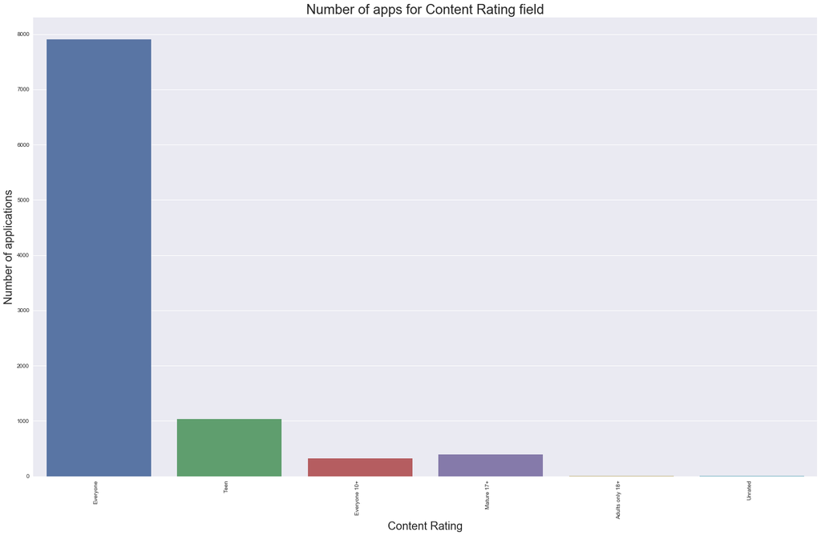

```python
g = sns.countplot(x="Content Rating",data=df)
g.set_xticklabels(g.get_xticklabels(), rotation=90, ha="right")
g.set_ylabel("Number of applications",fontsize=20)
g.set_xlabel("Content Rating",fontsize=20)
plt.title('Number of apps for Content Rating field',size = 24)
```

Com veiem, hi ha moltes més aplicacions que estan destinades a tothom, que a públic en general. Com es obvi, com més potencials clients tingui, millor.

Un cop ja hem vist la majoria de variables, anem a combinar-les per a observar millor els patrons.

Una de les primeres coses que se'ns acut és intentar veure la distribució del rating de les Apps en funció de la seva categoria.

```
Text(0.5,1,'Boxplot of Category VS Rating')
```

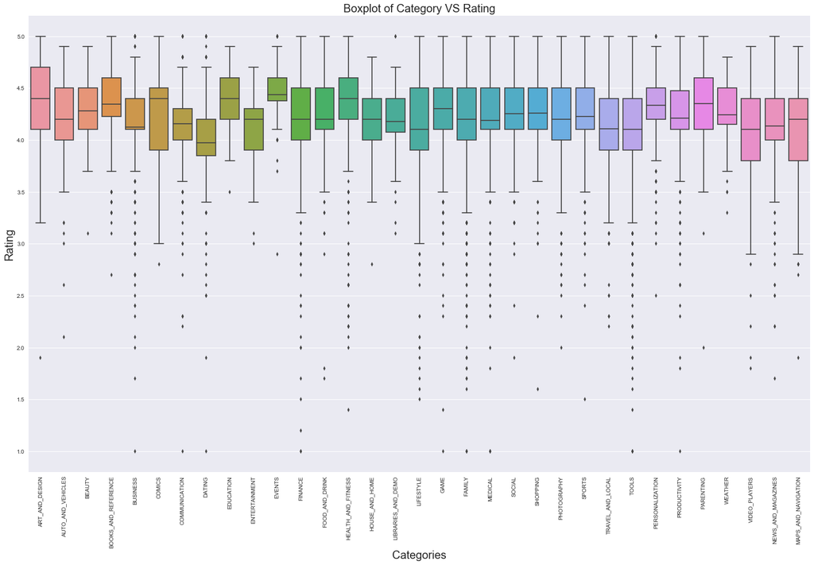

```python
g = sns.boxplot(x="Category",y="Rating",data=df)
g.set_xticklabels(g.get_xticklabels(),rotation=90)
g.set_ylabel("Rating",fontsize=20)
g.set_xlabel("Categories",fontsize=20)
plt.title('Boxplot of Category VS Rating',size = 20)
```

Com veiem, no hi ha grans variancions en la valoració en funció de la categoria. Totes tenen la seva mitjana al voltant de del 4.2 de rating.

Ara seria interessant veure si hi ha relació entre el Rating i el preu de la App i quina és la tendència:

```
Text(0.5,1,'Scatter plot Rating vs Price')
```

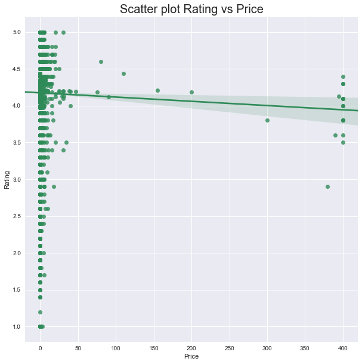

```python
plt.figure(figsize = (10,10))
sns.regplot(x="Price", y="Rating", color = 'seagreen',data=df);
plt.title('Scatter plot Rating vs Price',size = 20)
```

Com veiem, un aplicació cara no es garantia de tenir bona o mala valoració, ara bé, els client tendeixen a valorar-la pitjor en funció del preu que paguen. Com és lógic, quan més es paga, més li exigeixes a una App i és més probable que la valoris pitjor que si fos gratis.

Anem a veure el Rating en funció del número de instal·lacions. La lógica ens diria que les aplicacions més descarregades són les que tenen millor valoració:

```
Text(0.5,1,'Rating vs Installs')
```

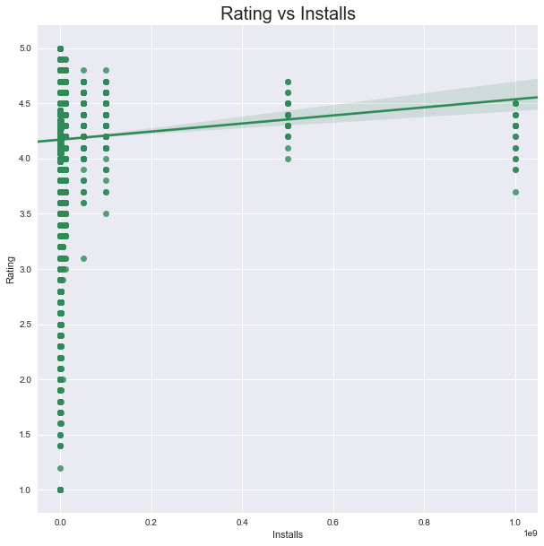

```python
plt.figure(figsize = (10,10))
sns.regplot(x="Installs", y="Rating", color = 'seagreen',data=df);
plt.title('Rating vs Installs',size = 20)
```

Veiem que la nostra hipotèsis era correcta. La tendència diu que com més instal·lacions hi hagi, més ben valorada estarà la App. Segurament és l'efecte del Play Store de recomanar-te les aplicacions més populars. També és un factor decisiu per atrevir-te a descarregar una App o no.

Ara bé, molts cops passa que no descarregues una app en funció dels megues que ocupa la App. Així que anem a veure com és aquesta tendència:

```
Text(0.5,1,'Installs vs Size')
```

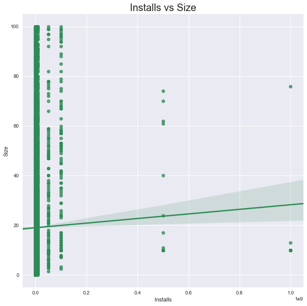

```python
plt.figure(figsize = (10,10))
sns.regplot(x="Installs", y="Size", color = 'seagreen',data=df);
plt.title('Installs vs Size',size = 20)
```

Veiem com això no és del tot cert, i que la gent no té en compte això a l'hora de descarregar-se una App. El fet que Google Play prioritzi la descàrrega en Wifi pot ser una de les claus en aquest camp.

Un altre factor en quant al nombre d'instal·lacions és el potencial públic que pugui tenir una App. Si està destinada a tothom, a priori hauriem de tenir més descarregues. Anem a mirar si això és cert:

```
Text(0.5,1,'Boxplot of Content Rating VS Installs')
```

[figure not shown]

```python
g = sns.boxplot(x="Content Rating",y="Installs",data=df[df['Installs'] < 1000000])
g.set_xticklabels(g.get_xticklabels(),rotation=90)
g.set_ylabel("Installs",fontsize=20)
g.set_xlabel("Content Rating",fontsize=20)
plt.title('Boxplot of Content Rating VS Installs',size = 20)
```

Veiem com realment el públic origen no és un factor de cara als usuaris per descarregar o no un App. El fet que el móvil ja sigui una eina majoritàriament d'un adult, ja fa la sel·lecció automática i això fa que els resultats no és vegin afectats. També veiem, com les aplicacions per Adults són molt descarregades, tanmateix la mostra és molt menor.

Una altra cosa que podria interessar a una empresa que estigués creant una aplicació, o tingués en ment dissenyar una, seria en quina categoria podria situar una App per a que tingués un preu que la gent estigués disposada a pagar. Això ho podem veure mirant com es distribueixen els preus de les App en funció de la categoria.

Això ho podem veure en el següent gràfic:

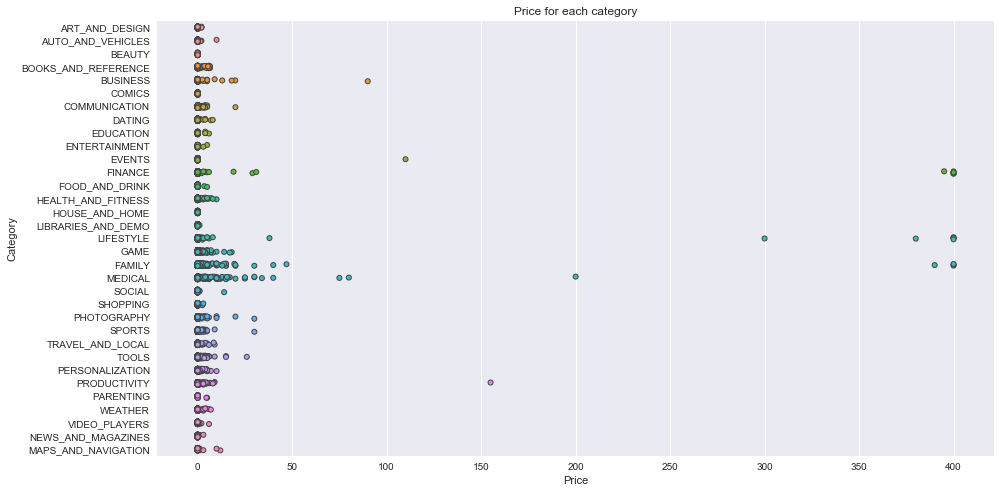

```python
fig, ax = plt.subplots()
fig.set_size_inches(15, 8)
p = sns.stripplot(x="Price", y="Category", data=df, jitter=True, linewidth=1)
title = ax.set_title('Price for each category')
```

Com veiem, si l'aplicació és de finances, lifestyle o familiar, podriem posar un preu més elevat a la nostre App.

### Conclusions

Un cop analitzat el dataset, si fossim una nova companyia que té en ment crear una nova app, hauriem de tenir en compte els següents punts:

- Si la nostre App es situa en les categories de Family and Games, tindrem molta més competència però es situarà en les categories que solen tenir més descarregues.
- Si l'aplicació està dins del genere de education, comics o events, és molt probable que tiguem un rating més alt. Per altra banda, si creem una App de dating, tot i que tindrem moltes descarregues tindrem males valoracions en mitjana.
- La mitjana de rating en qualsevol App sol ser 4,17, així que ens pot servir com a orientació per fixar els objectius o per firmar algún contracte.
- Si volem tenir moltes reviews, com és lógic, el que necesitem és tenir moltes descàrregues.
- Seria molt recomanable, per a no destacar negativament, que com a mínim, tinguessim com a versió mínima Android 4.1.
- El preu mitjà d'una app, si és de pagament que són la minoria, és de 1-3$, així que no hauriem de superar aquests valor.
- Si per el contrari, posem l'aplicació cara, els usuaris tendiran a exigir-nos més i per tant podem tenir valoracions més negatives que les que tindriem si fos gratis.